# EMBL PhD Course: clustering

Kitty Lo

09 July, 2018

In this workshop, we will be exploring a tissue expression dataset with the hierarchical clustering and k-means clustering algorithms, and visualise the dataset using heatmaps and dimension reduction tools. The material is adapted from here http://genomicsclass.github.io/book/pages/clustering_and_heatmaps.html

## Task 1

1. Download the tissuesGeneExpression dataset from Github: https://github.com/genomicsclass/tissuesGeneExpression/commits/master/data Load the dataset into R. Check that there is a 22215 by 189 matrix called `e` with rows as genes and columns as samples. Each sample is from different tissue and the true tissue label can be found in the variable `tissue`. Check that there are 7 tissue types.

```r
load("tissuesGeneExpression.rda")
dim(e)
```

```
## [1] 22215   189
```

```r
unique(tissue)
```

```
## [1] "kidney"      "hippocampus" "cerebellum"  "colon"       "liver"
## [6] "endometrium" "placenta"
```

2. Build a dendrogram using the R functions `dist` and `hclust`.

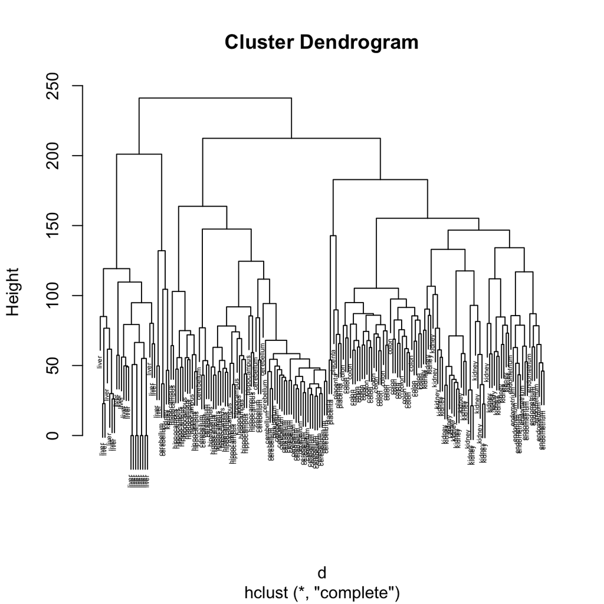

```r
d <- dist(t(e))
hc <- hclust(d)
plot(hc, labels=tissue, cex=0.4)
```

3. Using the result from `hclust`, extract the clusters from the tree using the `cutree` function. `cutree` allows you to either specify the number of clusters or specify the cut height. Try out different number of desired clusters and compare to the true tissue classes. How well does the hierarchical clustering algorithm perform at finding the tissue classes? Are there tissues that are more difficult to separate?

```r
hclusters <- cutree(hc,k=7)
table(true = tissue, cluster = hclusters )
```

```
##              cluster
## true           1  2  3  4  5  6  7
##   cerebellum   0  0 36  0  0  2  0
##   colon        0  0  0 34  0  0  0
##   endometrium 15  0  0  0  0  0  0
##   hippocampus  0 12 19  0  0  0  0
##   kidney      37  0  0  0  0  2  0
##   liver        0  0  0  0 24  2  0
##   placenta     0  0  0  0  0  0  6
```

4. Heatmaps are ubiquitous in biology, and they can usually be found to accompany dendrograms in publication figures. In this task, use the function `heatmap.2` from the `gplots` library. First, identify the top 50 genes with the highest variance in the expression dataset (You may find the function `apply` useful here). Then, using these 50 genes, build a heatmap using `heatmap.2` function. This function automatically adds dendrogram to the left and to the top of the heatmap.

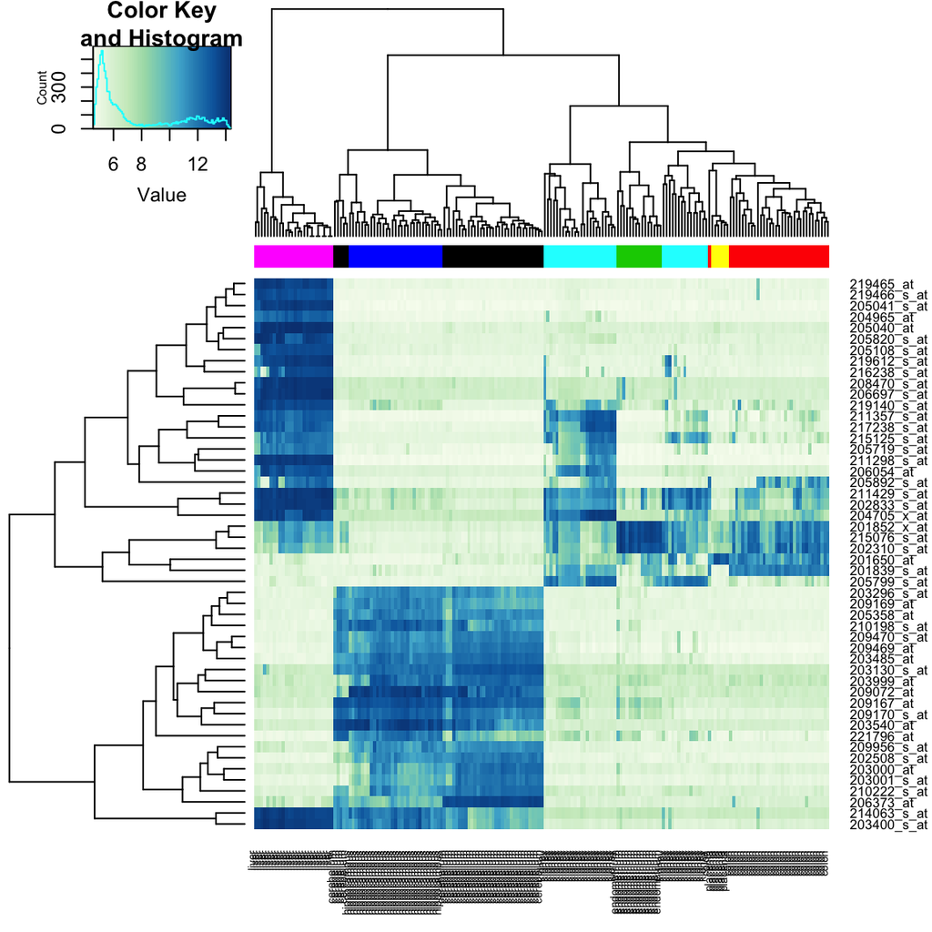

```r
library(gplots)
library(RColorBrewer)
rv <- apply(e, 1, var)
idx <- order(-rv)[1:50]
cols <- palette(brewer.pal(8, "Dark2"))[as.factor(tissue)]
hmcol <- colorRampPalette(brewer.pal(9, "GnBu"))(100)
heatmap.2(e[idx,], labCol=tissue,
           trace="none",
           ColSideColors=cols,
           col=hmcol)
```

(e) Now let’s try the k-means algorithm using the function `kmeans`.

```r
set.seed(1)
km <- kmeans(t(e), centers=7)
names(km)
```

```
## [1] "cluster"      "centers"      "totss"        "withinss"
## [5] "tot.withinss" "betweenss"    "size"         "iter"
## [9] "ifault"
```

```r
table(true=tissue,cluster=km$cluster)
```

```
##              cluster
## true           1  2  3  4  5  6  7
##   cerebellum   0  0  0  5  2  0 31
##   colon        0 34  0  0  0  0  0
##   endometrium 15  0  0  0  0  0  0
##   hippocampus  0  0  0 31  0  0  0
##   kidney       7  0 30  0  2  0  0
##   liver        0  0  0  0  2 24  0
##   placenta     0  6  0  0  0  0  0
```

## Task 2

In this task we will explore the dimension reduction techniques PCA and tSNE.

1. Use the R function `prcomp` to perform PCA on the tissue expression dataset and plot the first two PCA components. How many components is required to explain most of the variance in this datasets?

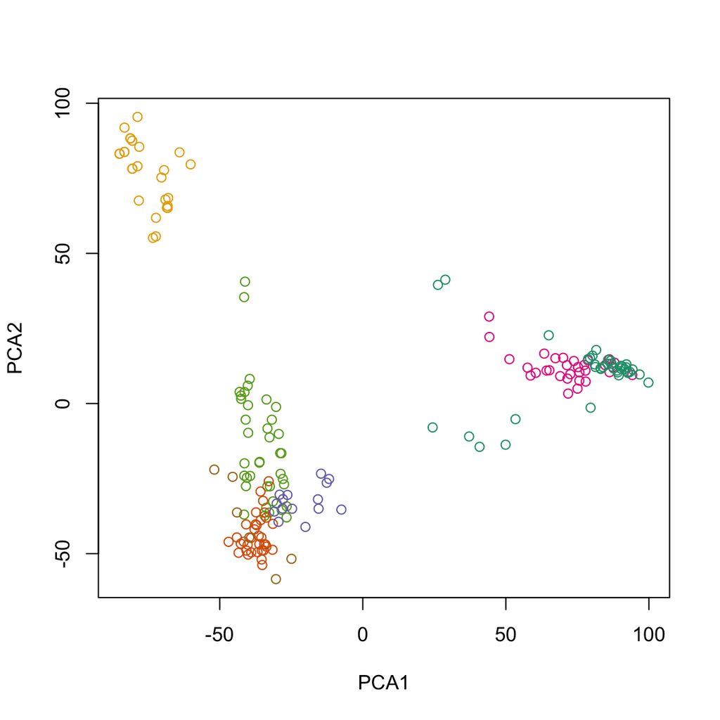

```r
pca.res <- prcomp(t(e))
plot(pca.res$x[,1], pca.res$x[,2], col = as.factor(tissue), xlab = "PCA1", ylab = "PCA2")
```

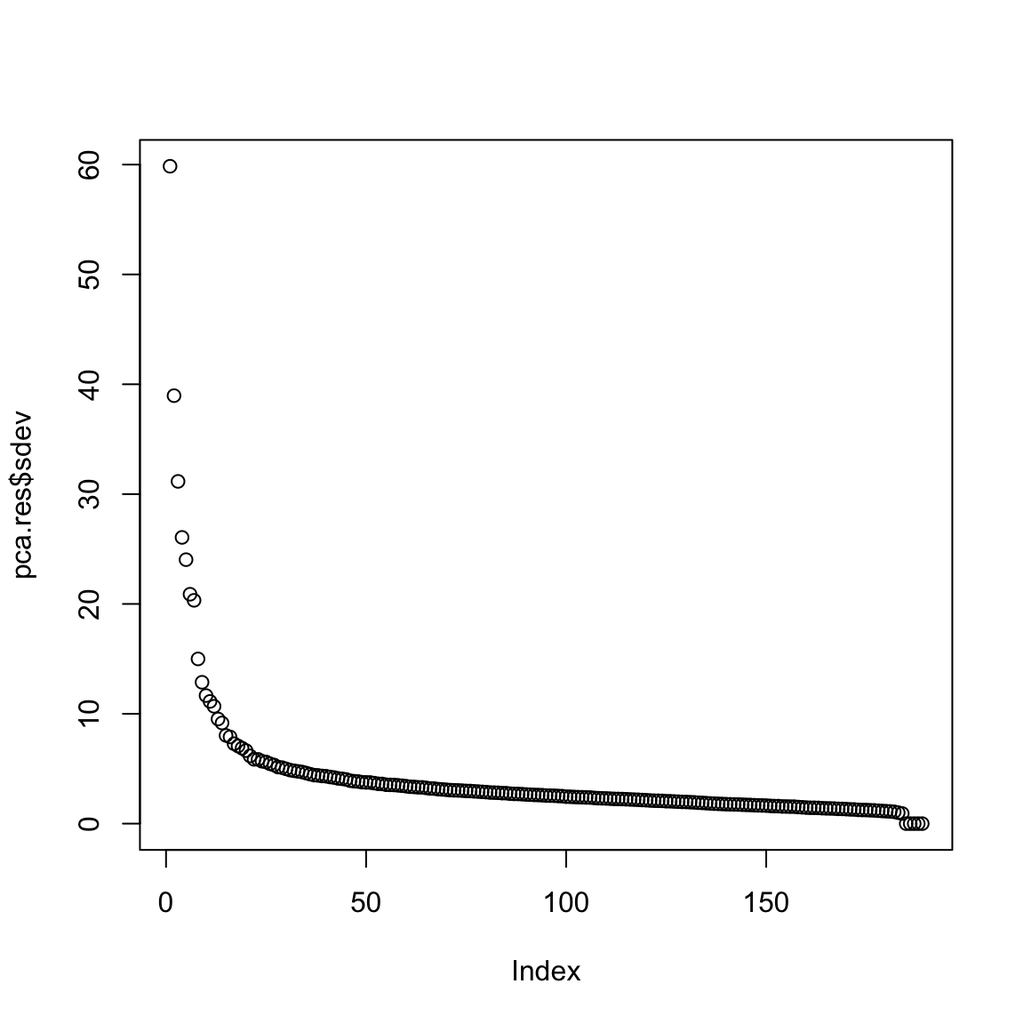

```r
plot(pca.res$sdev)
```

2. Download and install the `Rtsne` package if you haven’t already done so. Now perform tSNE on the tissue expression dataset using the `Rtsne` function. Visualise the results and overlay with the clusters found in Task 1. One of the key parameters in the tSNE algorithm is `perplexity`. Explore how changing the perplexity parameter changes the outputs.

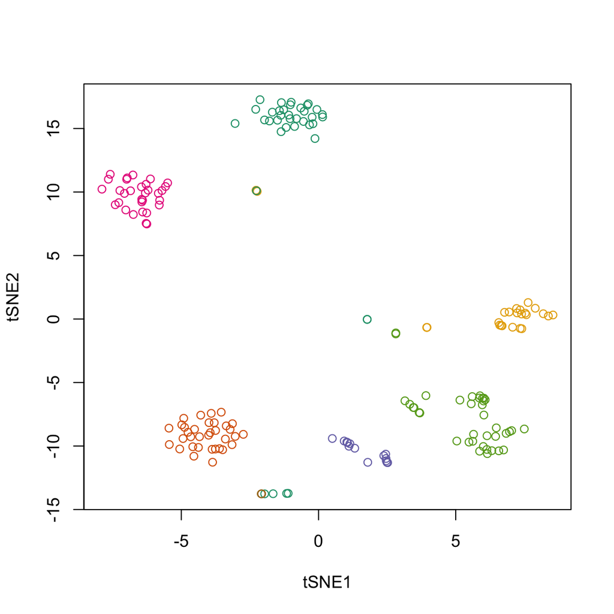

```r
library(Rtsne)
e.nodups <- e[,!duplicated(t(e))]
e.tsne <- Rtsne(t(e.nodups))
plot(e.tsne$Y[,1], e.tsne$Y[,2],col = as.factor(tissue), xlab = "tSNE1", ylab = "tSNE2")
```